# Project 1: Wrangling, Exploration, Visualization

SDS322E

## Data Wrangling, Exploration, Visualization

### Neel Panging (np22679)

#### Introduction

As someone who loves watching movies, I thought it would be interesting to gain insights on how movies are distributed across different streaming platforms (e.g. Netflix, Hulu, Prime Video). Because of this, I found a dataset [movie_platforms] which contains basic information about different movies, as well as which platforms they are streamed on. I’l be merging this dataset with the movie titles in [imdb_ratings], which contains information about the logistics of many different movies (budget, revenue, popularity, etc.)

movie_platforms: https://www.kaggle.com/ruchi798/movies-on-netflix-prime-video-hulu-and-disney imdb_ratings: https://www.kaggle.com/deepak525/investigate-tmdb-movie-dataset/data

```r
library(tidyverse)

imdb_ratings <- read_csv("https://docs.google.com/spreadsheets/d/e/2PACX-1vTkacJKVKsQl6wSSVH-P6PfNfjaFHsfee2TqgisGnjRFz3kI5hBSoi-HXiIFSWJ32YZz1zmrXmhu-K9/pub?gid=1329237387&single=true&output=csv")
movie_platforms <- read_csv("https://docs.google.com/spreadsheets/d/e/2PACX-1vQ4wIR2WKNke2OdgNLqskftEwxIih2vI-fpm-A2MQJkMi1nbpilY2MGOItEAuN7V0Wi9O0U667CDB9X/pub?gid=506178995&single=true&output=csv")
```

#### Tidying: Reshaping

These datasets are already tidy, so we don’t have to worry about that for now.

#### Joining/Merging

```r
nrow(movie_platforms)
```

```
## [1] 9515
```

```r
length(unique(movie_platforms$Title))
```

```
## [1] 9515
```

As for the movie_platforms dataset, there are 9515 rows and 9515 unique titles, implying that each row is unique to each movie

```r
nrow(imdb_ratings)  # all titles
```

```
## [1] 10866
```

```r
length(unique(imdb_ratings$original_title))  # unqiue titles
```

```
## [1] 10571
```

```r
imdb_title_freq <- data.frame(table(imdb_ratings$original_title))
repeats <- imdb_title_freq[imdb_title_freq$Freq > 1, ]
nrow(repeats)
```

```
## [1] 277
```

```r
repeats
```

```
##                           Var1 Freq
## 8                            1    2
## 152                          9    2
## 181          A Christmas Carol    3
## 271  A Nightmare on Elm Street    2
## 469                      Alfie    2
## 473                      Alice    2
## 475        Alice in Wonderland    3
## 659      And Soon the Darkness    2
## 686              Anna Karenina    2
## 692                      Annie    3
## 732           April Fool's Day    2
## 759                     Arthur    2
## 783     Assault on Precinct 13    2
## 791                     Asylum    2
```

[output cut: 37 more lines]

As for imdb_ratings, there seems to be repeated movie titles. This is because there are 10866 rows but 10571 unique titles. This makes sense because there can be multiple movies with the same title! The frequency table above show such such repeated titles. There seems to be 277 of these!

```r
imdb_ratings[imdb_ratings$original_title == "Alice in Wonderland",
    ]
```

```
## # A tibble: 3 x 21
##      id imdb_id popularity budget revenue original_title cast  homepage director
##   <dbl> <chr>        <dbl>  <dbl>   <dbl> <chr>          <chr> <chr>    <chr>
## 1 12155 tt1014…      5.57  2.00e8  1.03e9 Alice in Wond… Mia … http://… Tim Bur…
## 2 30923 tt0164…      0.253 2.10e7  0.     Alice in Wond… Tina… <NA>     Nick Wi…
## 3 34573 tt0088…      0.350 0.      0.     Alice in Wond… Nata… <NA>     Harry H…
## # … with 12 more variables: tagline <chr>, keywords <chr>, overview <chr>,
## #   runtime <dbl>, genres <chr>, production_companies <chr>,
## #   release_date <chr>, vote_count <dbl>, vote_average <dbl>,
## #   release_year <dbl>, budget_adj <dbl>, revenue_adj <dbl>
```

Based on the frequency table, one of the repeated movie titles is “Alice in Wonderland” as shown above. Upon further inspection it looks like there’s the popular verion of this movie (directed by Tim Burton), along with two other versions that seem to have lower **popularity** scores, and missing data for **revenue**. It doesn’t make too much sense to consider the versions with 0 for **revenue** or **budget**, so maybe we can try removing those movies later.

```r
imdb_ratings_filtered <- imdb_ratings %>% filter(revenue > 0) %>%
    filter(budget > 0)

imdb_title_freq <- data.frame(table(imdb_ratings_filtered$original_title))
repeats <- imdb_title_freq[imdb_title_freq$Freq > 1, ]
nrow(repeats)
```

```
## [1] 47
```

```r
repeats
```

```
##                              Var1 Freq
## 94      A Nightmare on Elm Street    2
## 234                         Annie    2
## 262                        Arthur    2
## 379                       Beowulf    2
## 551                        Carrie    2
## 557                 Casino Royale    2
## 622           Clash of the Titans    2
## 655           Conan the Barbarian    2
## 743              Dawn of the Dead    2
## 759            Death at a Funeral    2
## 826               Doctor Dolittle    2
## 987                     Fair Game    2
## 991                Fantastic Four    2
## 1054                    Footloose    2
```

[output cut: 33 more lines]

```r
imdb_ratings_filtered[imdb_ratings_filtered$original_title ==
    "A Nightmare on Elm Street", ]
```

```
## # A tibble: 2 x 21
##      id imdb_id popularity budget revenue original_title cast  homepage director
##   <dbl> <chr>        <dbl>  <dbl>   <dbl> <chr>          <chr> <chr>    <chr>
## 1 23437 tt1179…       1.07 3.50e7  1.16e8 A Nightmare o… Jack… http://… Samuel …
## 2   377 tt0087…       1.33 1.80e6  2.55e7 A Nightmare o… John… <NA>     Wes Cra…
## # … with 12 more variables: tagline <chr>, keywords <chr>, overview <chr>,
## #   runtime <dbl>, genres <chr>, production_companies <chr>,
## #   release_date <chr>, vote_count <dbl>, vote_average <dbl>,
## #   release_year <dbl>, budget_adj <dbl>, revenue_adj <dbl>
```

We’re now down to only 47 repeated movie titles in the frequency table, not bad! If we take a look at a Nightmare on Elm Street, it looks like there are two valid versions of this film, both with considerable **popularity**, **budget**, and **revenue**. We will repeat this process after merging our datasets

```r
merged <- imdb_ratings %>% left_join(movie_platforms, by = c(original_title = "Title"))
head(merged)
```

```
## # A tibble: 6 x 36
##       id imdb_id popularity budget revenue original_title cast  homepage
##    <dbl> <chr>        <dbl>  <dbl>   <dbl> <chr>          <chr> <chr>
## 1 135397 tt0369…      33.0  1.50e8  1.51e9 Jurassic World Chri… http://…
## 2  76341 tt1392…      28.4  1.50e8  3.78e8 Mad Max: Fury… Tom … http://…
## 3 262500 tt2908…      13.1  1.10e8  2.95e8 Insurgent      Shai… http://…
## 4 140607 tt2488…      11.2  2.00e8  2.07e9 Star Wars: Th… Harr… http://…
## 5 168259 tt2820…       9.34 1.90e8  1.51e9 Furious 7      Vin … http://…
## 6 281957 tt1663…       9.11 1.35e8  5.33e8 The Revenant   Leon… http://…
## # … with 28 more variables: director <chr>, tagline <chr>, keywords <chr>,
## #   overview <chr>, runtime <dbl>, genres <chr>, production_companies <chr>,
## #   release_date <chr>, vote_count <dbl>, vote_average <dbl>,
## #   release_year <dbl>, budget_adj <dbl>, revenue_adj <dbl>, ID <dbl>,
## #   Year <dbl>, Age <chr>, IMDb <chr>, `Rotten Tomatoes` <chr>, Netflix <dbl>,
## #   Hulu <dbl>, `Prime Video` <dbl>, `Disney+` <dbl>, Type <dbl>,
## #   Directors <chr>, Genres <chr>, Country <chr>, Language <chr>, Runtime <dbl>
```

I’ve merged these datasets by movie titles and decided to do an left_join imdb_ratings with movie_platforms to keep the movies with the same titles from imdb_ratings. This will result in movies with repeated titles being merged with information for the same unique title in movie_platforms. We will account for this during data wrangling.

```r
num_rows <- nrow(merged)
num_rows
```

```
## [1] 10866
```

```r
nrow(imdb_ratings) - num_rows
```

```
## [1] 0
```

```r
nrow(movie_platforms) - num_rows
```

```
## [1] -1351
```

After merging, it looks like our merged dataset has 10866 rows. Since we left joined from imdb_ratings, we currently have the same number of rows that imdb_ratings has, and 1351 more rows than movie_platforms. We are now ready to wrangle.

#### Wrangling

There are a lot of variables in our dataset now, so let’s only consider some of these for the purposes of this project. The variables of interest are noted in the *interested_cols* variable.

```r
colnames(merged)
```

```
##  [1] "id"                   "imdb_id"              "popularity"
##  [4] "budget"               "revenue"              "original_title"
##  [7] "cast"                 "homepage"             "director"
## [10] "tagline"              "keywords"             "overview"
## [13] "runtime"              "genres"               "production_companies"
## [16] "release_date"         "vote_count"           "vote_average"
## [19] "release_year"         "budget_adj"           "revenue_adj"
## [22] "ID"                   "Year"                 "Age"
## [25] "IMDb"                 "Rotten Tomatoes"      "Netflix"
## [28] "Hulu"                 "Prime Video"          "Disney+"
## [31] "Type"                 "Directors"            "Genres"
## [34] "Country"              "Language"             "Runtime"
```

```r
interested_cols <- c("original_title", "Year", "Netflix", "Hulu",
    "Prime Video", "Type", "Country", "Genres", "Language", "Runtime",
    "revenue", "Directors", "budget", "IMDb", "Rotten Tomatoes")
merged <- merged %>% select(interested_cols)
head(merged)
```

```
## # A tibble: 6 x 15
##   original_title  Year Netflix  Hulu `Prime Video`  Type Country Genres Language
##   <chr>          <dbl>   <dbl> <dbl>         <dbl> <dbl> <chr>   <chr>  <chr>
## 1 Jurassic World    NA      NA    NA            NA    NA <NA>    <NA>   <NA>
## 2 Mad Max: Fury…    NA      NA    NA            NA    NA <NA>    <NA>   <NA>
## 3 Insurgent         NA      NA    NA            NA    NA <NA>    <NA>   <NA>
## 4 Star Wars: Th…  2015       0     0             0     0 United… Actio… English
## 5 Furious 7         NA      NA    NA            NA    NA <NA>    <NA>   <NA>
## 6 The Revenant      NA      NA    NA            NA    NA <NA>    <NA>   <NA>
## # … with 6 more variables: Runtime <dbl>, revenue <dbl>, Directors <chr>,
## #   budget <dbl>, IMDb <chr>, `Rotten Tomatoes` <chr>
```

Now let’s do some more wrangling. Here we rename the columns and filter out the films that aren’t on Netflix, Hulu, or Prime Video. We also filtered out the films with 0 revenue/budget, which I’m assuming are films that are not as popular. This might help get rid of some of those duplicate films.

```r
# Renaming columns for easier referencing
oldnames = c("original_title", "Prime Video", "Rotten Tomatoes")
newnames = c("title", "prime", "rotten_tomatoes")
temp <- merged %>% rename_at(vars(oldnames), ~newnames) %>% rename_all(tolower) %>%
    # Filtering by movies either on Netflix, Hulu, or Prime
mutate(x = netflix + hulu + prime) %>% drop_na(x) %>% filter(x >
    0) %>% select(-c(x)) %>% filter(revenue > 0, budget > 0)
head(temp)
```

```
## # A tibble: 6 x 15
##   title  year netflix  hulu prime  type country genres language runtime revenue
##   <chr> <dbl>   <dbl> <dbl> <dbl> <dbl> <chr>   <chr>  <chr>      <dbl>   <dbl>
## 1 Insi…  2005       0     0     1     0 United… Anima… English…      95  8.54e8
## 2 Jupi…  2015       1     0     0     0 United… Actio… English…     127  1.84e8
## 3 The …  2015       1     0     0     0 United… Crime… English…     168  1.56e8
## 4 Cind…  1965       0     0     1     0 United… Comed… English       NA  5.42e8
## 5 Stev…  2015       1     0     0     0 United… Biogr… English      122  3.44e7
## 6 The …  2015       0     1     0     0 United… Drama… English…     112  4.26e7
## # … with 4 more variables: directors <chr>, budget <dbl>, imdb <chr>,
## #   rotten_tomatoes <chr>
```

Using the frequency table method as shown earlier for repeated movie titles, we see that we now only have 11 repeated titles, but our dataset has been getting considerably smaller after our wrangling (699 rows).

```r
merged_freq <- data.frame(table(temp$title))
repeats <- merged_freq[merged_freq$Freq > 1, ]
nrow(repeats)
```

```
## [1] 11
```

```r
repeats
```

```
##               Var1 Freq
## 57         Beowulf    2
## 84   Casino Royale    2
## 160      Footloose    2
## 262         Legend    2
## 361         Psycho    2
## 380     Robin Hood    2
## 381        RoboCop    2
## 468         TEKKEN    2
## 545 The Karate Kid    2
## 633   Total Recall    2
## 653        Unknown    2
```

```r
temp[temp$title == "The Karate Kid", ]
```

```
## # A tibble: 2 x 15
##   title  year netflix  hulu prime  type country genres language runtime revenue
##   <chr> <dbl>   <dbl> <dbl> <dbl> <dbl> <chr>   <chr>  <chr>      <dbl>   <dbl>
## 1 The …  1984       1     0     0     0 United… Actio… English…     126  3.58e8
## 2 The …  1984       1     0     0     0 United… Actio… English…     126  9.08e7
## # … with 4 more variables: directors <chr>, budget <dbl>, imdb <chr>,
## #   rotten_tomatoes <chr>
```

To take care of the rest of these repeated titles, we are making the assumption that the Netflix/Hulu/Prime film among the duplicated films in the dataset is the film with the greatest revenue (i.e. greatest popularity). By following this assumption, we see that we now have unique movie titles in the dataset. Now let’s take care of some other wrangling.

```r
temp <- temp %>% group_by(title) %>% filter(revenue == max(revenue)) %>%
    distinct(title, .keep_all = TRUE)
nrow(temp) - length(unique(temp$title))
```

```
## [1] 0
```

Here I have written a function to return the number of instances for each of the categorical variables. This function is used to engineer some new numerical variables from our existing categorical ones. Also, the rating variables were parsed to be numeric.

```r
# Function to count values for our non-numeric columns
count_elements <- function(x) {
    length(unlist(str_split(x, ",")))
}

# Parsing ratings
temp <- temp %>% separate(imdb, c("imdb", "x"), sep = "/") %>%
    separate(rotten_tomatoes, c("rotten_tomatoes", "x"), sep = "/") %>%
    select(-c(x)) %>% # Engineering numeric 'count' variables from our categorical
# variables
mutate(ncountry = count_elements(country)) %>% mutate(ngenres = count_elements(genres)) %>%
    mutate(nlanguage = count_elements(language)) %>% mutate(ndirectors = count_elements(directors))
```

### Summary Statistics

The following are summary statistics for the numerical variables in the dataset

```r
df <- temp %>% ungroup()
df_num <- df %>% select(where(is.numeric)) %>% drop_na %>% summarize_all(funs(min = min,
    q25 = quantile(., 0.25), median = median, q75 = quantile(.,
        0.75), max = max, mean = mean, sd = sd, count = n(),
    distinct = n_distinct))

# use of gather/spread use of gt styling
library(gt)
df_num_stats <- df_num %>% gather(stat, val) %>% separate(stat,
    c("var", "stat"), sep = "_") %>% spread(stat, val) %>% select(var,
    min, q25, median, q75, max, mean, sd, count, distinct) %>%
    gt() %>% data_color(columns = vars(max), colors = scales::col_numeric(palette = c("#ffffff",
    "#f2fbd2", "#c9ecb4", "#93d3ab", "#35b0ab"), domain = NULL))
df_num_stats
```

| var | min | q25 | median | q75 | max | mean | sd | count | distinct |
| --- | --- | --- | --- | --- | --- | --- | --- | --- | --- |
| budget | 3 | 11000000 | 25000000 | 55000000 | 200000000 | 3.864229e+07 | 3.950776e+07 | 684 | 151 |
| hulu | 0 | 0 | 0 | 1 | 1 | 2.923977e-01 | 4.551969e-01 | 684 | 2 |
| ncountry | 1 | 1 | 1 | 2 | 8 | 1.678363e+00 | 1.112448e+00 | 684 | 8 |
| ndirectors | 1 | 1 | 1 | 1 | 13 | 1.092105e+00 | 5.427512e-01 | 684 | 4 |
| netflix | 0 | 0 | 0 | 1 | 1 | 4.005848e-01 | 4.903755e-01 | 684 | 2 |
| ngenres | 1 | 2 | 3 | 4 | 9 | 3.141813e+00 | 1.264010e+00 | 684 | 8 |
| nlanguage | 1 | 1 | 1 | 2 | 10 | 1.657895e+00 | 1.068618e+00 | 684 | 9 |
| prime | 0 | 0 | 0 | 1 | 1 | 4.108187e-01 | 4.923424e-01 | 684 | 2 |
| revenue | 2 | 15008118 | 48790986 | 133108214 | 1108561013 | 1.038102e+08 | 1.489892e+08 | 684 | 679 |
| runtime | 22 | 94 | 105 | 118 | 213 | 1.072997e+02 | 2.100141e+01 | 684 | 95 |
| type | 0 | 0 | 0 | 0 | 0 | 0.000000e+00 | 0.000000e+00 | 684 | 1 |
| year | 1922 | 1999 | 2008 | 2012 | 2021 | 2.003402e+03 | 1.377100e+01 | 684 | 65 |

The following is the frequency distribution for the categorical variables

```r
# Country
df %>% group_by(country) %>% summarise(n = n()) %>% mutate(freq = n/sum(n)) %>%
    arrange(desc(n))
```

```
## # A tibble: 142 x 3
##    country                          n    freq
##    <chr>                        <int>   <dbl>
##  1 United States                  377 0.548
##  2 United States,Canada            29 0.0422
##  3 United States,United Kingdom    25 0.0363
##  4 United Kingdom,United States    20 0.0291
##  5 United States,Germany           13 0.0189
##  6 United Kingdom                  12 0.0174
##  7 Canada                           8 0.0116
##  8 Germany,United States            8 0.0116
##  9 India                            6 0.00872
## 10 United States,Mexico             6 0.00872
## # … with 132 more rows
```

```r
df %>% group_by(genres) %>% summarise(n = n()) %>% mutate(freq = n/sum(n)) %>%
    arrange(desc(n))
```

```
## # A tibble: 292 x 3
##    genres                          n   freq
##    <chr>                       <int>  <dbl>
##  1 Comedy                         25 0.0363
##  2 Comedy,Drama,Romance           23 0.0334
##  3 Comedy,Romance                 22 0.0320
##  4 Comedy,Drama                   20 0.0291
##  5 Drama                          19 0.0276
##  6 Horror,Mystery,Thriller        19 0.0276
##  7 Crime,Drama,Thriller           16 0.0233
##  8 Action,Crime,Drama,Thriller    14 0.0203
##  9 Action,Crime,Thriller          14 0.0203
## 10 Drama,Romance                  14 0.0203
## # … with 282 more rows
```

```r
df %>% group_by(language) %>% summarise(n = n()) %>% mutate(freq = n/sum(n)) %>%
    arrange(desc(n))
```

```
## # A tibble: 140 x 3
##    language              n    freq
##    <chr>             <int>   <dbl>
##  1 English             407 0.592
##  2 English,Spanish      40 0.0581
##  3 English,French       19 0.0276
##  4 English,German       13 0.0189
##  5 English,Russian      12 0.0174
##  6 English,Italian      10 0.0145
##  7 English,Mandarin      7 0.0102
##  8 English,Cantonese     5 0.00727
##  9 English,Japanese      5 0.00727
## 10 English,Latin         5 0.00727
## # … with 130 more rows
```

```r
df %>% group_by(directors) %>% summarise(n = n()) %>% mutate(freq = n/sum(n)) %>%
    arrange(desc(n))
```

```
## # A tibble: 509 x 3
##    directors                n    freq
##    <chr>                <int>   <dbl>
##  1 <NA>                    16 0.0233
##  2 Oliver Stone             5 0.00727
##  3 Steven Spielberg         5 0.00727
##  4 Barry Levinson           4 0.00581
##  5 David Fincher            4 0.00581
##  6 Jay Roach                4 0.00581
##  7 Martin Scorsese          4 0.00581
##  8 Paul Thomas Anderson     4 0.00581
##  9 William Friedkin         4 0.00581
## 10 Woody Allen              4 0.00581
## # … with 499 more rows
```

The following is the number of missing values for each variable

```r
df %>% summarise_all(funs(sum(is.na(.))))
```

```
## # A tibble: 1 x 19
##   title  year netflix  hulu prime  type country genres language runtime revenue
##   <int> <int>   <int> <int> <int> <int>   <int>  <int>    <int>   <int>   <int>
## 1     0     0       0     0     0     0       2      0        4       4       0
## # … with 8 more variables: directors <int>, budget <int>, imdb <int>,
## #   rotten_tomatoes <int>, ncountry <int>, ngenres <int>, nlanguage <int>,
## #   ndirectors <int>
```

Now let’s do some other miscelleanous analyses. Firstly, it seems that films that are on Netflix have typically had higher revenue on average than films on Hulu or Prime video.

```r
df %>% group_by(netflix, hulu, prime) %>% summarize(mean_revenue = mean(revenue)) %>%
    arrange(desc(mean_revenue))
```

```
## # A tibble: 7 x 4
## # Groups:   netflix, hulu [4]
##   netflix  hulu prime mean_revenue
##     <dbl> <dbl> <dbl>        <dbl>
## 1       1     1     0   270114664.
## 2       1     0     0   133398925.
## 3       0     1     0   114196038.
## 4       1     0     1   105843162.
## 5       1     1     1    68906784
## 6       0     0     1    64217540.
## 7       0     1     1    63364020
```

Let’s look at how Steven Spielberg’s movies are distributed

```r
df %>% filter(str_detect(directors, "Spielberg")) %>% select(title,
    year, netflix, hulu, prime, revenue, budget, imdb, rotten_tomatoes,
    ndirectors) %>% arrange(desc(revenue))
```

```
## # A tibble: 5 x 10
##   title  year netflix  hulu prime revenue budget imdb  rotten_tomatoes
##   <chr> <dbl>   <dbl> <dbl> <dbl>   <dbl>  <dbl> <chr> <chr>
## 1 E.T.…  1982       0     0     1  7.93e8 1.05e7 7.8   83
## 2 The …  2011       0     1     0  3.72e8 1.30e8 7.3   77
## 3 Catc…  2002       0     1     0  3.52e8 5.20e7 8.1   87
## 4 A.I.…  2001       0     0     1  2.36e8 1.00e8 7.2   79
## 5 The …  2004       1     0     1  2.19e8 6.00e7 7.4   82
## # … with 1 more variable: ndirectors <int>
```

Now let’s compute the difference between the highest and lowest rated movie on Netflix for each given year.

```r
# Custom range statistic function
range <- function(x) {
    max(x) - min(x)
}

df %>% group_by(netflix, year) %>% mutate(rotten_tomatoes = as.numeric(rotten_tomatoes)) %>%
    filter(netflix == 1) %>% summarize(rotten_tomatoes_range = range(rotten_tomatoes)) %>%
    arrange(desc(rotten_tomatoes_range))
```

```
## # A tibble: 42 x 3
## # Groups:   netflix [1]
##    netflix  year rotten_tomatoes_range
##      <dbl> <dbl>                 <dbl>
##  1       1  1998                    50
##  2       1  2015                    45
##  3       1  2018                    42
##  4       1  2010                    41
##  5       1  2012                    39
##  6       1  2008                    34
##  7       1  2006                    28
##  8       1  1991                    26
##  9       1  2013                    25
## 10       1  2009                    24
## # … with 32 more rows
```

#### Visualizing

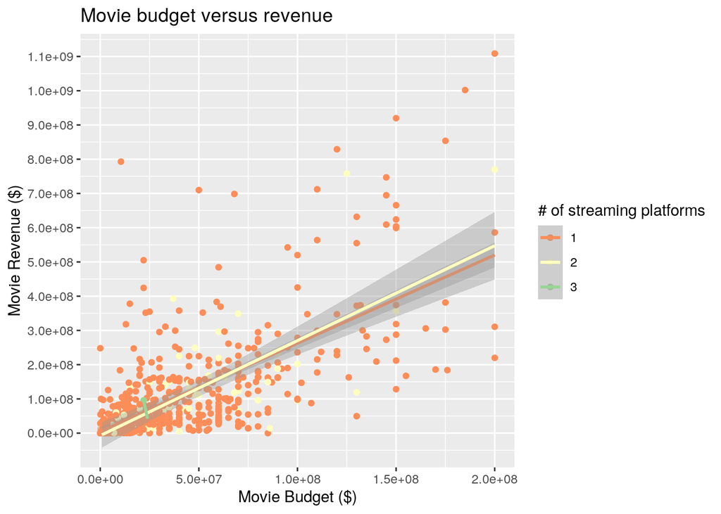

```r
library(ggplot2)
myColors <- c("#56ddc5", "#ff3db7", "#4699dd")
df %>% mutate(num_platforms = netflix + hulu + prime) %>% ggplot(aes(x = budget,
    y = revenue, color = as.factor(num_platforms))) + scale_colour_brewer(type = "seq",
    palette = "Spectral") + geom_point() + geom_smooth(method = "lm") +
    xlab("Movie Budget ($)") + ylab("Movie Revenue ($)") + ggtitle("Movie budget versus revenue") +
    labs(color = "# of streaming platforms") + scale_y_continuous(breaks = scales::pretty_breaks(n = 10))
```

As shown in the plot above, there is a relatively linear correlation between movie budget and movie revenue. This makes sense because higher budget films can afford to pay higher profile actors and staff, which could totally affect how many people would pay to watch such a movie. Also, the data points are colored by # of streaming platforms (i.e. the number of streaming platforms that the movie appears on out of Netflix, Hulu, and Amazon). I definitely expected more of the high budget/high revenue films to be on multiple streaming platforms, but most of these films were still on 1 streaming platform.

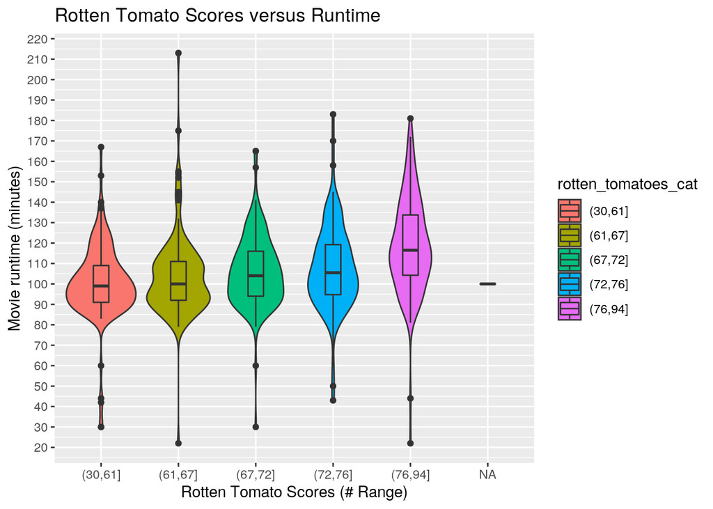

```r
df %>% mutate(rotten_tomatoes = as.numeric(rotten_tomatoes)) %>%
    mutate(rotten_tomatoes_cat = cut(rotten_tomatoes, breaks = quantile(rotten_tomatoes,
        probs = seq(0, 1, 0.2)))) %>% ggplot(aes(x = rotten_tomatoes_cat,
    y = runtime, fill = rotten_tomatoes_cat)) + geom_violin() +
    theme_grey() + geom_boxplot(width = 0.2) + xlab("Rotten Tomato Scores (# Range)") +
    ylab("Movie runtime (minutes)") + ggtitle("Rotten Tomato Scores versus Runtime") +
    labs(color = "Rotten Tomato Scores") + scale_y_continuous(breaks = scales::pretty_breaks(n = 20))
```

The plot above is a box-plot overlayed with a violin plot of movie run times across different Rotten Tomato score ranges. I did this by creating the categorical variable **rotten_tomatoes_cat** by binning **rotten_tomatoes** into 5 bins. As shown in the plot, it seems that the median runtimes of the movies seem to be greater for the more highly rated movies. In fact, it looks like the first quartile for the run time of the highest Rotten Tomato Score category seems to be around than the median run time of the other score categories. Maybe longer runtimes give movies more time to show how good they are!

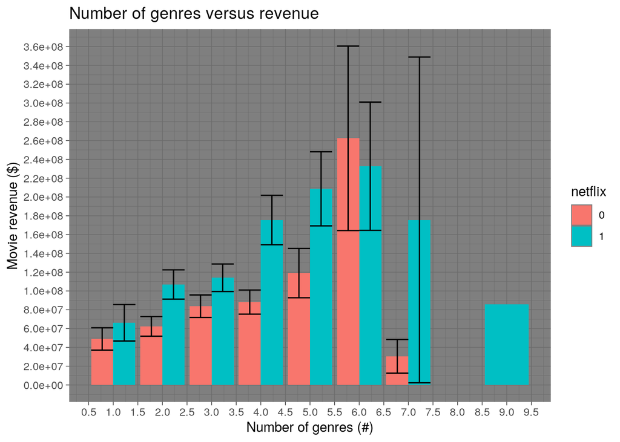

```r
df %>% mutate(across(c(netflix), factor)) %>% ggplot(aes(x = ngenres,
    y = revenue, fill = netflix)) + theme_dark() + geom_bar(stat = "summary",
    position = "dodge") + geom_errorbar(stat = "summary", position = "dodge") +
    scale_x_continuous(breaks = scales::pretty_breaks(n = 20)) +
    scale_y_continuous(breaks = scales::pretty_breaks(n = 20)) +
    xlab("Number of genres (#)") + ylab("Movie revenue ($)") +
    ggtitle("Number of genres versus revenue") + labs(color = "On Netflix")
```